# Project 1: Boston & Seattle Airbnb Data Analysis

Yu Tao 2021/03/22

## 1. Business Understanding

In this notebook, I will look at the Boston and Seattle Airbnb data, and try to answer several business questions:

- (1) How does the price of an Airbnb home vary by time?
- (2) What is the monthly occupancy of a common Airbnb home?
- (3) How much does an Airbnb home cost, given its property and room type?
- (4) How does the neighborhood affect the price of the Airbnb home?
- (5) How to predict the price of an Airbnb home give some of its properties?
- (6) How are super hosts and regular hosts reviewed by their customers?

The answers to these business questions can be helpful for the Airbnb hosts to better understand the values of their properties, and are also important for the customers to get a satisfactory Airbnb service that meets their own requirements. I will handle these problems using descriptive statistics and a linear regression model.

## 2. Data Understanding

The [Boston](https://www.kaggle.com/airbnb/boston) and [Seattle](https://www.kaggle.com/airbnb/seattle/data) Airbnb data are obtained from Kaggle. The following Airbnb activity is included in both datasets:

- Listings, including full descriptions and average review score
- Reviews, including unique id for each reviewer and detailed comments
- Calendar, including listing id and the price and availability for that day

I will begin by importing the necessary libraries and loading the datasets.

### 2.1 Import libraries

```python
# import libraries needed for this porject
import numpy as np
import pandas as pd
import seaborn as sns
import matplotlib.pyplot as plt

import missingno as ms # visualize missing data
import calendar # convert datetime

# linear model to predict price
from sklearn.linear_model import LinearRegression
from sklearn.model_selection import train_test_split
from sklearn.metrics import r2_score

%matplotlib inline
```

### 2.2 Load the datasets

```python
# load the datasets
df_sea_listings = pd.read_csv("seattle_listings.csv")
df_sea_reviews = pd.read_csv("seattle_reviews.csv")
df_sea_calendar = pd.read_csv("seattle_calendar.csv")

df_bos_listings = pd.read_csv("boston_listings.csv")
df_bos_reviews = pd.read_csv("boston_reviews.csv")
df_bos_calendar = pd.read_csv("boston_calendar.csv")
```

### 2.3 Basic info of the data

Let's check the basic information of the Seattle datasets, using methods like head(), info(), and visualize the missing values.

```python
df_sea_listings.head()
```

|  | id | listing_url | scrape_id | last_scraped | name | summary | space | description | experiences_offered | neighborhood_overview | ... | review_scores_value | requires_license | license | jurisdiction_names | instant_bookable | cancellation_policy | require_guest_profile_picture | require_guest_phone_verification | calculated_host_listings_count | reviews_per_month |
| --- | --- | --- | --- | --- | --- | --- | --- | --- | --- | --- | --- | --- | --- | --- | --- | --- | --- | --- | --- | --- | --- |
| 0 | 241032 | https://www.airbnb.com/rooms/241032 | 20160104002432 | 2016-01-04 | Stylish Queen Anne Apartment | NaN | Make your self at home in this charming one-be... | Make your self at home in this charming one-be... | none | NaN | ... | 10.0 | f | NaN | WASHINGTON | f | moderate | f | f | 2 | 4.07 |
| 1 | 953595 | https://www.airbnb.com/rooms/953595 | 20160104002432 | 2016-01-04 | Bright & Airy Queen Anne Apartment | Chemically sensitive? We've removed the irrita... | Beautiful, hypoallergenic apartment in an extr... | Chemically sensitive? We've removed the irrita... | none | Queen Anne is a wonderful, truly functional vi... | ... | 10.0 | f | NaN | WASHINGTON | f | strict | t | t | 6 | 1.48 |
| 2 | 3308979 | https://www.airbnb.com/rooms/3308979 | 20160104002432 | 2016-01-04 | New Modern House-Amazing water view | New modern house built in 2013. Spectacular s... | Our house is modern, light and fresh with a wa... | New modern house built in 2013. Spectacular s... | none | Upper Queen Anne is a charming neighborhood fu... | ... | 10.0 | f | NaN | WASHINGTON | f | strict | f | f | 2 | 1.15 |
| 3 | 7421966 | https://www.airbnb.com/rooms/7421966 | 20160104002432 | 2016-01-04 | Queen Anne Chateau | A charming apartment that sits atop Queen Anne... | NaN | A charming apartment that sits atop Queen Anne... | none | NaN | ... | NaN | f | NaN | WASHINGTON | f | flexible | f | f | 1 | NaN |
| 4 | 278830 | https://www.airbnb.com/rooms/278830 | 20160104002432 | 2016-01-04 | Charming craftsman 3 bdm house | Cozy family craftman house in beautiful neighb... | Cozy family craftman house in beautiful neighb... | Cozy family craftman house in beautiful neighb... | none | We are in the beautiful neighborhood of Queen ... | ... | 9.0 | f | NaN | WASHINGTON | f | strict | f | f | 1 | 0.89 |

5 rows × 92 columns

```python
df_sea_listings.columns
```

```
Index(['id', 'listing_url', 'scrape_id', 'last_scraped', 'name', 'summary',
       'space', 'description', 'experiences_offered', 'neighborhood_overview',
       'notes', 'transit', 'thumbnail_url', 'medium_url', 'picture_url',
       'xl_picture_url', 'host_id', 'host_url', 'host_name', 'host_since',
       'host_location', 'host_about', 'host_response_time',
       'host_response_rate', 'host_acceptance_rate', 'host_is_superhost',
       'host_thumbnail_url', 'host_picture_url', 'host_neighbourhood',
       'host_listings_count', 'host_total_listings_count',
       'host_verifications', 'host_has_profile_pic', 'host_identity_verified',
       'street', 'neighbourhood', 'neighbourhood_cleansed',
       'neighbourhood_group_cleansed', 'city', 'state', 'zipcode', 'market',
       'smart_location', 'country_code', 'country', 'latitude', 'longitude',
       'is_location_exact', 'property_type', 'room_type', 'accommodates',
       'bathrooms', 'bedrooms', 'beds', 'bed_type', 'amenities', 'square_feet',
       'price', 'weekly_price', 'monthly_price', 'security_deposit',
       'cleaning_fee', 'guests_included', 'extra_people', 'minimum_nights',
       'maximum_nights', 'calendar_updated', 'has_availability',
       'availability_30', 'availability_60', 'availability_90',
       'availability_365', 'calendar_last_scraped', 'number_of_reviews',
       'first_review', 'last_review', 'review_scores_rating',
       'review_scores_accuracy', 'review_scores_cleanliness',
       'review_scores_checkin', 'review_scores_communication',
       'review_scores_location', 'review_scores_value', 'requires_license',
       'license', 'jurisdiction_names', 'instant_bookable',
       'cancellation_policy', 'require_guest_profile_picture',
       'require_guest_phone_verification', 'calculated_host_listings_count',
       'reviews_per_month'],
      dtype='object')
```

```python
df_sea_listings.info()
```

```
<class 'pandas.core.frame.DataFrame'>
RangeIndex: 3818 entries, 0 to 3817
Data columns (total 92 columns):
id                                  3818 non-null int64
listing_url                         3818 non-null object
scrape_id                           3818 non-null int64
last_scraped                        3818 non-null object
name                                3818 non-null object
summary                             3641 non-null object
space                               3249 non-null object
description                         3818 non-null object
experiences_offered                 3818 non-null object
neighborhood_overview               2786 non-null object
notes                               2212 non-null object
transit                             2884 non-null object
thumbnail_url                       3498 non-null object
medium_url                          3498 non-null object
picture_url                         3818 non-null object
xl_picture_url                      3498 non-null object
host_id                             3818 non-null int64
host_url                            3818 non-null object
host_name                           3816 non-null object
host_since                          3816 non-null object
host_location                       3810 non-null object
host_about                          2959 non-null object
host_response_time                  3295 non-null object
host_response_rate                  3295 non-null object
host_acceptance_rate                3045 non-null object
host_is_superhost                   3816 non-null object
host_thumbnail_url                  3816 non-null object
host_picture_url                    3816 non-null object
host_neighbourhood                  3518 non-null object
host_listings_count                 3816 non-null float64
host_total_listings_count           3816 non-null float64
host_verifications                  3818 non-null object
host_has_profile_pic                3816 non-null object
host_identity_verified              3816 non-null object
street                              3818 non-null object
neighbourhood                       3402 non-null object
neighbourhood_cleansed              3818 non-null object
```

[output cut: 42 more lines]

```
review_scores_checkin               3160 non-null float64
review_scores_communication         3167 non-null float64
review_scores_location              3163 non-null float64
review_scores_value                 3162 non-null float64
requires_license                    3818 non-null object
license                             0 non-null float64
jurisdiction_names                  3818 non-null object
instant_bookable                    3818 non-null object
cancellation_policy                 3818 non-null object
require_guest_profile_picture       3818 non-null object
require_guest_phone_verification    3818 non-null object
calculated_host_listings_count      3818 non-null int64
reviews_per_month                   3191 non-null float64
dtypes: float64(17), int64(13), object(62)
memory usage: 2.7+ MB
```

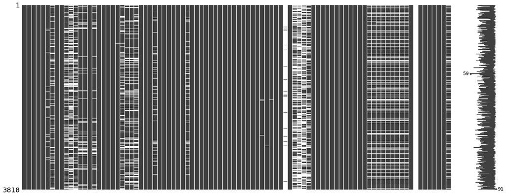

```python
ms.matrix(df_sea_listings)
```

```python
df_sea_reviews.head()
```

|  | listing_id | id | date | reviewer_id | reviewer_name | comments |
| --- | --- | --- | --- | --- | --- | --- |
| 0 | 7202016 | 38917982 | 2015-07-19 | 28943674 | Bianca | Cute and cozy place. Perfect location to every... |
| 1 | 7202016 | 39087409 | 2015-07-20 | 32440555 | Frank | Kelly has a great room in a very central locat... |
| 2 | 7202016 | 39820030 | 2015-07-26 | 37722850 | Ian | Very spacious apartment, and in a great neighb... |
| 3 | 7202016 | 40813543 | 2015-08-02 | 33671805 | George | Close to Seattle Center and all it has to offe... |
| 4 | 7202016 | 41986501 | 2015-08-10 | 34959538 | Ming | Kelly was a great host and very accommodating ... |

```python
df_sea_reviews.info()
```

```
<class 'pandas.core.frame.DataFrame'>
RangeIndex: 84849 entries, 0 to 84848
Data columns (total 6 columns):
listing_id       84849 non-null int64
id               84849 non-null int64
date             84849 non-null object
reviewer_id      84849 non-null int64
reviewer_name    84849 non-null object
comments         84831 non-null object
dtypes: int64(3), object(3)
memory usage: 3.9+ MB
```

```python
df_sea_calendar.head()
```

|  | listing_id | date | available | price |
| --- | --- | --- | --- | --- |
| 0 | 241032 | 2016-01-04 | t | $85.00 |
| 1 | 241032 | 2016-01-05 | t | $85.00 |
| 2 | 241032 | 2016-01-06 | f | NaN |
| 3 | 241032 | 2016-01-07 | f | NaN |
| 4 | 241032 | 2016-01-08 | f | NaN |

```python
df_sea_calendar.info()
```

```
<class 'pandas.core.frame.DataFrame'>
RangeIndex: 1393570 entries, 0 to 1393569
Data columns (total 4 columns):
listing_id    1393570 non-null int64
date          1393570 non-null object
available     1393570 non-null object
price         934542 non-null object
dtypes: int64(1), object(3)
memory usage: 42.5+ MB
```

similarly, let's look at the basic information of the Boston datasets, using methods like head(), info(), and visualize the missing values.

```python
df_bos_listings.head()
```

|  | id | listing_url | scrape_id | last_scraped | name | summary | space | description | experiences_offered | neighborhood_overview | ... | review_scores_value | requires_license | license | jurisdiction_names | instant_bookable | cancellation_policy | require_guest_profile_picture | require_guest_phone_verification | calculated_host_listings_count | reviews_per_month |
| --- | --- | --- | --- | --- | --- | --- | --- | --- | --- | --- | --- | --- | --- | --- | --- | --- | --- | --- | --- | --- | --- |
| 0 | 12147973 | https://www.airbnb.com/rooms/12147973 | 20160906204935 | 2016-09-07 | Sunny Bungalow in the City | Cozy, sunny, family home. Master bedroom high... | The house has an open and cozy feel at the sam... | Cozy, sunny, family home. Master bedroom high... | none | Roslindale is quiet, convenient and friendly. ... | ... | NaN | f | NaN | NaN | f | moderate | f | f | 1 | NaN |
| 1 | 3075044 | https://www.airbnb.com/rooms/3075044 | 20160906204935 | 2016-09-07 | Charming room in pet friendly apt | Charming and quiet room in a second floor 1910... | Small but cozy and quite room with a full size... | Charming and quiet room in a second floor 1910... | none | The room is in Roslindale, a diverse and prima... | ... | 9.0 | f | NaN | NaN | t | moderate | f | f | 1 | 1.30 |
| 2 | 6976 | https://www.airbnb.com/rooms/6976 | 20160906204935 | 2016-09-07 | Mexican Folk Art Haven in Boston | Come stay with a friendly, middle-aged guy in ... | Come stay with a friendly, middle-aged guy in ... | Come stay with a friendly, middle-aged guy in ... | none | The LOCATION: Roslindale is a safe and diverse... | ... | 10.0 | f | NaN | NaN | f | moderate | t | f | 1 | 0.47 |
| 3 | 1436513 | https://www.airbnb.com/rooms/1436513 | 20160906204935 | 2016-09-07 | Spacious Sunny Bedroom Suite in Historic Home | Come experience the comforts of home away from... | Most places you find in Boston are small howev... | Come experience the comforts of home away from... | none | Roslindale is a lovely little neighborhood loc... | ... | 10.0 | f | NaN | NaN | f | moderate | f | f | 1 | 1.00 |
| 4 | 7651065 | https://www.airbnb.com/rooms/7651065 | 20160906204935 | 2016-09-07 | Come Home to Boston | My comfy, clean and relaxing home is one block... | Clean, attractive, private room, one block fro... | My comfy, clean and relaxing home is one block... | none | I love the proximity to downtown, the neighbor... | ... | 10.0 | f | NaN | NaN | f | flexible | f | f | 1 | 2.25 |

5 rows × 95 columns

```python
df_bos_listings.columns
```

```
Index(['id', 'listing_url', 'scrape_id', 'last_scraped', 'name', 'summary',
       'space', 'description', 'experiences_offered', 'neighborhood_overview',
       'notes', 'transit', 'access', 'interaction', 'house_rules',
       'thumbnail_url', 'medium_url', 'picture_url', 'xl_picture_url',
       'host_id', 'host_url', 'host_name', 'host_since', 'host_location',
       'host_about', 'host_response_time', 'host_response_rate',
       'host_acceptance_rate', 'host_is_superhost', 'host_thumbnail_url',
       'host_picture_url', 'host_neighbourhood', 'host_listings_count',
       'host_total_listings_count', 'host_verifications',
       'host_has_profile_pic', 'host_identity_verified', 'street',
       'neighbourhood', 'neighbourhood_cleansed',
       'neighbourhood_group_cleansed', 'city', 'state', 'zipcode', 'market',
       'smart_location', 'country_code', 'country', 'latitude', 'longitude',
       'is_location_exact', 'property_type', 'room_type', 'accommodates',
       'bathrooms', 'bedrooms', 'beds', 'bed_type', 'amenities', 'square_feet',
       'price', 'weekly_price', 'monthly_price', 'security_deposit',
       'cleaning_fee', 'guests_included', 'extra_people', 'minimum_nights',
       'maximum_nights', 'calendar_updated', 'has_availability',
       'availability_30', 'availability_60', 'availability_90',
       'availability_365', 'calendar_last_scraped', 'number_of_reviews',
       'first_review', 'last_review', 'review_scores_rating',
       'review_scores_accuracy', 'review_scores_cleanliness',
       'review_scores_checkin', 'review_scores_communication',
       'review_scores_location', 'review_scores_value', 'requires_license',
       'license', 'jurisdiction_names', 'instant_bookable',
       'cancellation_policy', 'require_guest_profile_picture',
       'require_guest_phone_verification', 'calculated_host_listings_count',
       'reviews_per_month'],
      dtype='object')
```

```python
df_bos_listings.info()
```

```
<class 'pandas.core.frame.DataFrame'>
RangeIndex: 3585 entries, 0 to 3584
Data columns (total 95 columns):
id                                  3585 non-null int64
listing_url                         3585 non-null object
scrape_id                           3585 non-null int64
last_scraped                        3585 non-null object
name                                3585 non-null object
summary                             3442 non-null object
space                               2528 non-null object
description                         3585 non-null object
experiences_offered                 3585 non-null object
neighborhood_overview               2170 non-null object
notes                               1610 non-null object
transit                             2295 non-null object
access                              2096 non-null object
interaction                         2031 non-null object
house_rules                         2393 non-null object
thumbnail_url                       2986 non-null object
medium_url                          2986 non-null object
picture_url                         3585 non-null object
xl_picture_url                      2986 non-null object
host_id                             3585 non-null int64
host_url                            3585 non-null object
host_name                           3585 non-null object
host_since                          3585 non-null object
host_location                       3574 non-null object
host_about                          2276 non-null object
host_response_time                  3114 non-null object
host_response_rate                  3114 non-null object
host_acceptance_rate                3114 non-null object
host_is_superhost                   3585 non-null object
host_thumbnail_url                  3585 non-null object
host_picture_url                    3585 non-null object
host_neighbourhood                  3246 non-null object
host_listings_count                 3585 non-null int64
host_total_listings_count           3585 non-null int64
host_verifications                  3585 non-null object
host_has_profile_pic                3585 non-null object
host_identity_verified              3585 non-null object
```

[output cut: 45 more lines]

```
review_scores_checkin               2765 non-null float64
review_scores_communication         2767 non-null float64
review_scores_location              2763 non-null float64
review_scores_value                 2764 non-null float64
requires_license                    3585 non-null object
license                             0 non-null float64
jurisdiction_names                  0 non-null float64
instant_bookable                    3585 non-null object
cancellation_policy                 3585 non-null object
require_guest_profile_picture       3585 non-null object
require_guest_phone_verification    3585 non-null object
calculated_host_listings_count      3585 non-null int64
reviews_per_month                   2829 non-null float64
dtypes: float64(18), int64(15), object(62)
memory usage: 2.6+ MB
```

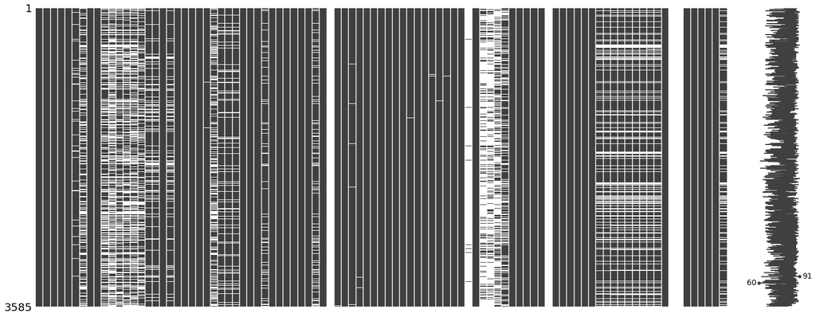

```python
ms.matrix(df_bos_listings)
```

```python
df_bos_reviews.head()
```

|  | listing_id | id | date | reviewer_id | reviewer_name | comments |
| --- | --- | --- | --- | --- | --- | --- |
| 0 | 1178162 | 4724140 | 2013-05-21 | 4298113 | Olivier | My stay at islam's place was really cool! Good... |
| 1 | 1178162 | 4869189 | 2013-05-29 | 6452964 | Charlotte | Great location for both airport and city - gre... |
| 2 | 1178162 | 5003196 | 2013-06-06 | 6449554 | Sebastian | We really enjoyed our stay at Islams house. Fr... |
| 3 | 1178162 | 5150351 | 2013-06-15 | 2215611 | Marine | The room was nice and clean and so were the co... |
| 4 | 1178162 | 5171140 | 2013-06-16 | 6848427 | Andrew | Great location. Just 5 mins walk from the Airp... |

```python
df_bos_reviews.info()
```

```
<class 'pandas.core.frame.DataFrame'>
RangeIndex: 68275 entries, 0 to 68274
Data columns (total 6 columns):
listing_id       68275 non-null int64
id               68275 non-null int64
date             68275 non-null object
reviewer_id      68275 non-null int64
reviewer_name    68275 non-null object
comments         68222 non-null object
dtypes: int64(3), object(3)
memory usage: 3.1+ MB
```

```python
df_bos_calendar.head()
```

|  | listing_id | date | available | price |
| --- | --- | --- | --- | --- |
| 0 | 12147973 | 2017-09-05 | f | NaN |
| 1 | 12147973 | 2017-09-04 | f | NaN |
| 2 | 12147973 | 2017-09-03 | f | NaN |
| 3 | 12147973 | 2017-09-02 | f | NaN |
| 4 | 12147973 | 2017-09-01 | f | NaN |

```python
df_bos_calendar.info()
```

```
<class 'pandas.core.frame.DataFrame'>
RangeIndex: 1308890 entries, 0 to 1308889
Data columns (total 4 columns):
listing_id    1308890 non-null int64
date          1308890 non-null object
available     1308890 non-null object
price         643037 non-null object
dtypes: int64(1), object(3)
memory usage: 39.9+ MB
```

## 3. Prepare Data

Depending on the business questions, we need to prepare the data in different ways, to reiterate, here are the questions we posted before, we will handle them one at a time.

- (1) How does the price of an Airbnb home vary by time?
- (2) What is the monthly occupancy of a common Airbnb home?
- (3) How much does an Airbnb home cost, given its property and room type?
- (4) How does the neighborhood affect the price of the Airbnb home?
- (5) How to predict the price of an Airbnb home give some of its properties?
- (6) How are super hosts and regular hosts reviewed by their customers?

### 3.1 Distribiton of Airbnb price

To answer this question, we'll need to focus on the price, monthly price and weekly price columns in the listings dataframes. We need to convert the values in these columns to float type and remove the dollar symbol, let's do it now.

```python
# convert some price values to float type
df_sea_listings["price"]=df_sea_listings.price.str.replace('$','').str.replace(',','').astype(float)
df_sea_listings["weekly_price"]=df_sea_listings.weekly_price.str.replace('$','').str.replace(',','').astype(float)
df_sea_listings["monthly_price"]=df_sea_listings.monthly_price.str.replace('$','').str.replace(',','').astype(float)
df_sea_listings["extra_people"]=df_sea_listings.extra_people.str.replace('$','').str.replace(',','').astype(float)

df_bos_listings["price"]=df_bos_listings.price.str.replace('$','').str.replace(',','').astype(float)
df_bos_listings["weekly_price"]=df_bos_listings.weekly_price.str.replace('$','').str.replace(',','').astype(float)
df_bos_listings["monthly_price"]=df_bos_listings.monthly_price.str.replace('$','').str.replace(',','').astype(float)
df_bos_listings["extra_people"]=df_bos_listings.extra_people.str.replace('$','').str.replace(',','').astype(float)
```

I will plot the price distribution of all Airbnb homes in Boston and Seattle, also I set the limit at $500/night.

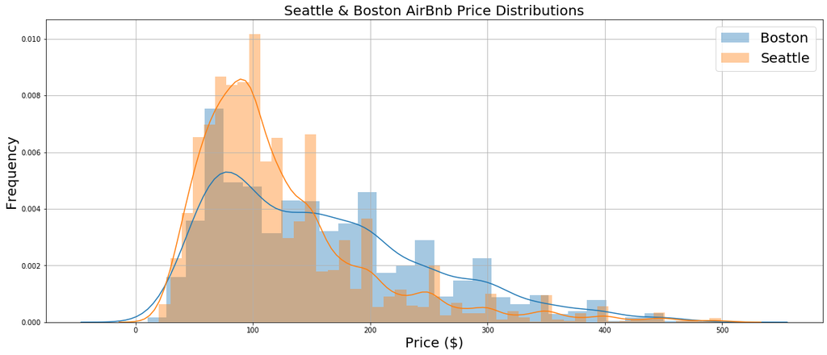

```python
# price histogram
plt.figure(figsize=(20, 8))
sns.distplot(df_bos_listings[df_bos_listings['price'] < 500]['price'], label='Boston')
sns.distplot(df_sea_listings[df_sea_listings['price'] < 500]['price'], label='Seattle')
plt.legend(fontsize=20)
plt.grid('on')
plt.title('Seattle & Boston AirBnb Price Distributions', fontsize=20)
plt.xlabel('Price ($)', fontsize=20)
plt.ylabel('Frequency', fontsize=20)
plt.show()
```

For monthly price and weekly price, we'll need to first merge the listings and calendar dataframes, then groupby either month or week and find the average price of Airbnb.

```python
# merge listings and calendar dataframe
df_sea_listings=df_sea_listings.rename(columns={'id':'listing_id'})
df_bos_listings=df_bos_listings.rename(columns={'id':'listing_id'})
df_sea_ls_cal=pd.merge(df_sea_listings, df_sea_calendar, on='listing_id', how='inner')
df_bos_ls_cal=pd.merge(df_bos_listings, df_bos_calendar, on='listing_id', how='inner')
```

```python
# convert date to date time format
df_sea_ls_cal['date'] = pd.to_datetime(df_sea_ls_cal['date'])
df_sea_ls_cal['host_since'] = pd.to_datetime(df_sea_ls_cal['host_since'])
df_sea_ls_cal['month']=df_sea_ls_cal.date.dt.month.apply(lambda x: calendar.month_abbr[x])
df_sea_ls_cal['year']=df_sea_ls_cal.host_since.dt.year

df_bos_ls_cal['date'] = pd.to_datetime(df_bos_ls_cal['date'])
df_bos_ls_cal['host_since'] = pd.to_datetime(df_bos_ls_cal['host_since'])
df_bos_ls_cal['month']=df_bos_ls_cal.date.dt.month.apply(lambda x: calendar.month_abbr[x])
df_bos_ls_cal['year']=df_bos_ls_cal.host_since.dt.year
```

```python
# check the column names
df_sea_ls_cal.columns
```

```
Index(['listing_id', 'listing_url', 'scrape_id', 'last_scraped', 'name',
       'summary', 'space', 'description', 'experiences_offered',
       'neighborhood_overview', 'notes', 'transit', 'thumbnail_url',
       'medium_url', 'picture_url', 'xl_picture_url', 'host_id', 'host_url',
       'host_name', 'host_since', 'host_location', 'host_about',
       'host_response_time', 'host_response_rate', 'host_acceptance_rate',
       'host_is_superhost', 'host_thumbnail_url', 'host_picture_url',
       'host_neighbourhood', 'host_listings_count',
       'host_total_listings_count', 'host_verifications',
       'host_has_profile_pic', 'host_identity_verified', 'street',
       'neighbourhood', 'neighbourhood_cleansed',
       'neighbourhood_group_cleansed', 'city', 'state', 'zipcode', 'market',
       'smart_location', 'country_code', 'country', 'latitude', 'longitude',
       'is_location_exact', 'property_type', 'room_type', 'accommodates',
       'bathrooms', 'bedrooms', 'beds', 'bed_type', 'amenities', 'square_feet',
       'price_x', 'weekly_price', 'monthly_price', 'security_deposit',
       'cleaning_fee', 'guests_included', 'extra_people', 'minimum_nights',
       'maximum_nights', 'calendar_updated', 'has_availability',
       'availability_30', 'availability_60', 'availability_90',
       'availability_365', 'calendar_last_scraped', 'number_of_reviews',
       'first_review', 'last_review', 'review_scores_rating',
       'review_scores_accuracy', 'review_scores_cleanliness',
       'review_scores_checkin', 'review_scores_communication',
       'review_scores_location', 'review_scores_value', 'requires_license',
       'license', 'jurisdiction_names', 'instant_bookable',
       'cancellation_policy', 'require_guest_profile_picture',
       'require_guest_phone_verification', 'calculated_host_listings_count',
       'reviews_per_month', 'date', 'available', 'price_y', 'month', 'year'],
      dtype='object')
```

```python
# change to float type for price_y column
df_sea_ls_cal["price_y"]=df_sea_ls_cal.price_y.str.replace('$','').str.replace(',','').astype(float)
df_bos_ls_cal["price_y"]=df_bos_ls_cal.price_y.str.replace('$','').str.replace(',','').astype(float)
```

```python
# calculate rate average over month
df_sea_monthly_price = df_sea_ls_cal.groupby(['month'])['price_y'].mean().to_frame(name='seattle_price').reset_index()
df_bos_monthly_price = df_bos_ls_cal.groupby(['month'])['price_y'].mean().to_frame(name='boston_price').reset_index()
```

```python
# merge month price from both cities
df_monthly_price=pd.merge(df_sea_monthly_price, df_bos_monthly_price, on='month', how='inner')
```

```python
print (df_monthly_price)
```

```
   month  seattle_price  boston_price
0    Apr     135.097005    197.252890
1    Aug     150.656594    203.330142
2    Dec     137.251835    192.601915
3    Feb     124.293927    180.961028
4    Jan     122.912176    182.799671
5    Jul     152.094150    202.486309
6    Jun     147.473137    196.535302
7    Mar     128.644488    181.818742
8    May     139.538183    193.712295
9    Nov     135.688738    202.924416
10   Oct     137.031939    233.416248
11   Sep     143.255949    237.047727
```

```python
# reorder the mothly price dataframe
months=['Jan', 'Feb', 'Mar', 'Apr', 'May', 'Jun', 'Jul', 'Aug', 'Sep', 'Oct', 'Nov', 'Dec']
mapping = {month: i for i, month in enumerate(months)}
key = df_monthly_price['month'].map(mapping)
df_monthly_price = df_monthly_price.iloc[key.argsort()]
```

```python
df_monthly_price
```

|  | month | seattle_price | boston_price |
| --- | --- | --- | --- |
| 4 | Jan | 122.912176 | 182.799671 |
| 3 | Feb | 124.293927 | 180.961028 |
| 7 | Mar | 128.644488 | 181.818742 |
| 0 | Apr | 135.097005 | 197.252890 |
| 8 | May | 139.538183 | 193.712295 |
| 6 | Jun | 147.473137 | 196.535302 |
| 5 | Jul | 152.094150 | 202.486309 |
| 1 | Aug | 150.656594 | 203.330142 |
| 11 | Sep | 143.255949 | 237.047727 |
| 10 | Oct | 137.031939 | 233.416248 |
| 9 | Nov | 135.688738 | 202.924416 |
| 2 | Dec | 137.251835 | 192.601915 |

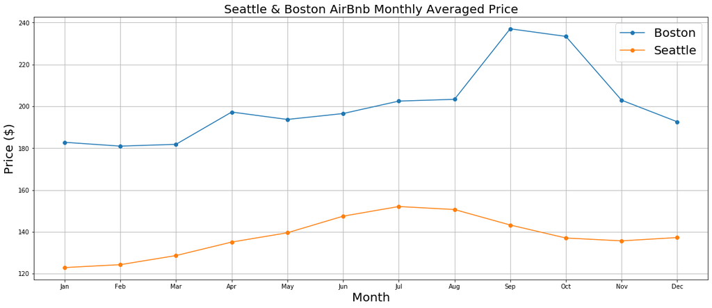

```python
# plot monthly price
plt.figure(figsize=(20,8))
plt.plot(df_monthly_price['month'], df_monthly_price['boston_price'], 'o-', label = 'Boston')
plt.plot(df_monthly_price['month'], df_monthly_price['seattle_price'], 'o-', label = 'Seattle')
plt.title('Seattle & Boston AirBnb Monthly Averaged Price',fontsize=20)
plt.xlabel('Month',fontsize=20)
plt.ylabel('Price ($)',fontsize=20)
plt.legend(fontsize=20)
plt.grid('on')
plt.show()
```

Similarly let's obtain the weekly price distribution.

```python
# groupby day of week and find the average price
df_sea_week_price = df_sea_ls_cal.groupby(df_sea_ls_cal['date'].dt.strftime('%w'))['price_y'].mean().to_frame(name='sea_price').reset_index()
df_bos_week_price = df_bos_ls_cal.groupby(df_bos_ls_cal['date'].dt.strftime('%w'))['price_y'].mean().to_frame(name='bos_price').reset_index()
df_sea_week_price['date'] = df_sea_week_price['date'].replace(['0','1','2','3','4','5','6'], ['Mon','Tue','Wed','Thu','Fri','Sat','Sun'])
df_bos_week_price['date'] = df_bos_week_price['date'].replace(['0','1','2','3','4','5','6'], ['Mon','Tue','Wed','Thu','Fri','Sat','Sun'])

df_weekly_price=pd.merge(df_sea_week_price, df_bos_week_price, on='date', how='inner')
```

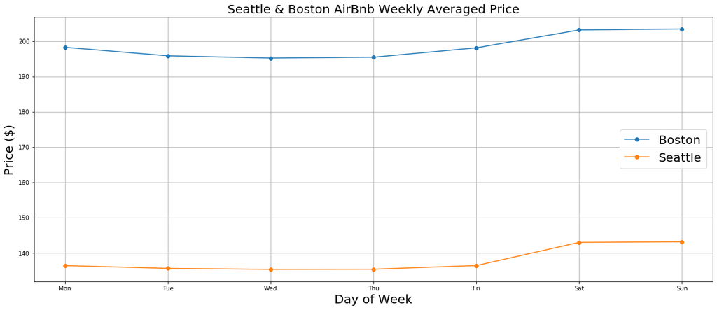

```python
# plot weekly price
plt.figure(figsize=(20,8))
plt.plot(df_weekly_price['date'], df_weekly_price['bos_price'], 'o-', label = 'Boston')
plt.plot(df_weekly_price['date'], df_weekly_price['sea_price'], 'o-', label = 'Seattle')
plt.title('Seattle & Boston AirBnb Weekly Averaged Price', fontsize=20)
plt.xlabel('Day of Week', fontsize=20)
plt.ylabel('Price ($)', fontsize=20)
plt.legend(fontsize=20)
plt.grid('on')
plt.show()
```

Next I will plot the Airbnb price history.

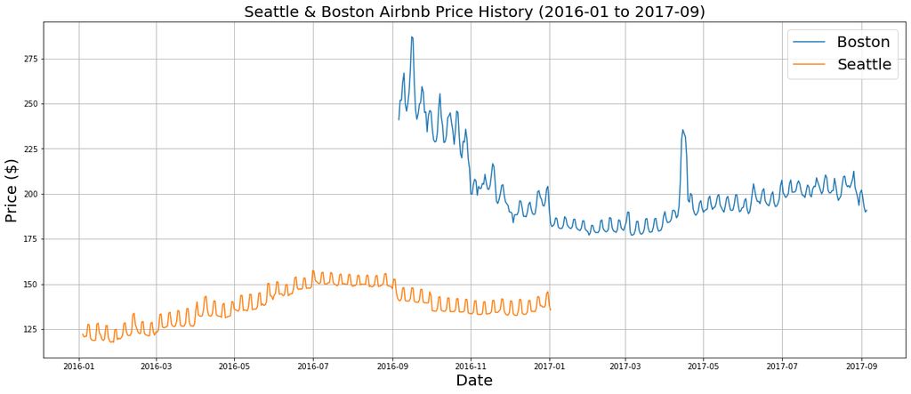

```python
# history price
plt.figure(figsize = (20, 8))
plt.plot(df_bos_ls_cal.groupby(['date'])['price_y'].mean(), label = 'Boston')
plt.plot(df_sea_ls_cal.groupby(['date'])['price_y'].mean(), label = 'Seattle')
plt.title('Seattle & Boston Airbnb Price History (2016-01 to 2017-09)', fontsize=20)
plt.xlabel('Date', fontsize=20)
plt.ylabel('Price ($)', fontsize=20)
plt.legend(fontsize=20)
plt.grid('on')
```

### 3.2 Monthly occupancy of Airbnb

For this question, we will need to look at the available column of the merge dataframe and pick out the rows that indicated 'f', which implies non-availability.

```python
# define a new column occupancy
df_sea_ls_cal['occupancy'] = df_sea_ls_cal['available'] == 'f'
df_bos_ls_cal['occupancy'] = df_bos_ls_cal['available'] == 'f'
```

```python
# group by month and find the occupancy in each month by calculating the mean on that column
df_sea_month_occupancy = df_sea_ls_cal.groupby(df_sea_ls_cal['date'].dt.strftime('%m'))['occupancy'].mean().to_frame(name='sea_occupancy').reset_index()
df_sea_month_occupancy['month'] = df_sea_month_occupancy['date'].replace(['01','02','03','04','05','06','07','08','09','10','11','12'], ['Jan', 'Feb', 'Mar', 'Apr', 'May', 'Jun', 'Jul', 'Aug', 'Sep', 'Oct', 'Nov', 'Dec'])
df_bos_month_occupancy = df_bos_ls_cal.groupby(df_bos_ls_cal['date'].dt.strftime('%m'))['occupancy'].mean().to_frame(name='bos_occupancy').reset_index()
df_bos_month_occupancy['month'] = df_bos_month_occupancy['date'].replace(['01','02','03','04','05','06','07','08','09','10','11','12'], ['Jan', 'Feb', 'Mar', 'Apr', 'May', 'Jun', 'Jul', 'Aug', 'Sep', 'Oct', 'Nov', 'Dec'])

df_month_occupancy=pd.merge(df_sea_month_occupancy,df_bos_month_occupancy,on='month',how='inner')
```

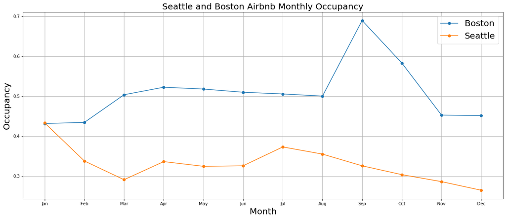

```python
# plot monthly occupancy
plt.figure(figsize=(20,8))
plt.plot(df_month_occupancy['month'], df_month_occupancy['bos_occupancy'], 'o-', label = 'Boston')
plt.plot(df_month_occupancy['month'], df_month_occupancy['sea_occupancy'], 'o-', label = 'Seattle')
plt.title('Seattle and Boston Airbnb Monthly Occupancy',fontsize=20)
plt.xlabel('Month',fontsize=20)
plt.ylabel('Occupancy',fontsize=20)
plt.legend(fontsize=20)
plt.grid('on')
plt.show()
```

### 3.3 Rate for different room types and property types

This question is fairly straightforward, we look at the room type and property type, and I will first make count plot for these columns to see how many samples were included each, then we will look at their individual mean price.

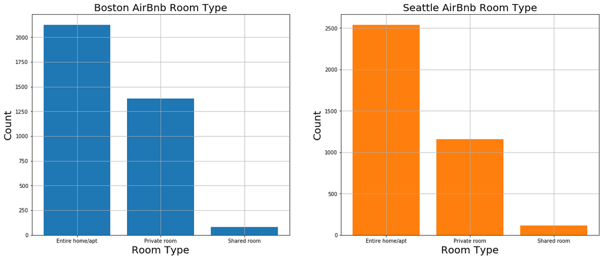

```python
# count plot on room type
fig, ax = plt.subplots(figsize = (20,8))
ax1 = plt.subplot(121)
ax1.set_title('Boston AirBnb Room Type', fontsize=20)
ax1.bar(df_bos_listings['room_type'].value_counts().index,
        df_bos_listings['room_type'].value_counts().values,
        color='tab:blue')
plt.xlabel('Room Type', fontsize=20)
plt.ylabel('Count', fontsize=20)
plt.grid('on')

ax2 = plt.subplot(122)
ax2.set_title('Seattle AirBnb Room Type', fontsize=20)
ax2.bar(df_sea_listings['room_type'].value_counts().index,
        df_sea_listings['room_type'].value_counts().values,
        color='tab:orange')
plt.xlabel('Room Type', fontsize=20)
plt.ylabel('Count', fontsize=20)
plt.grid('on')
plt.show()
```

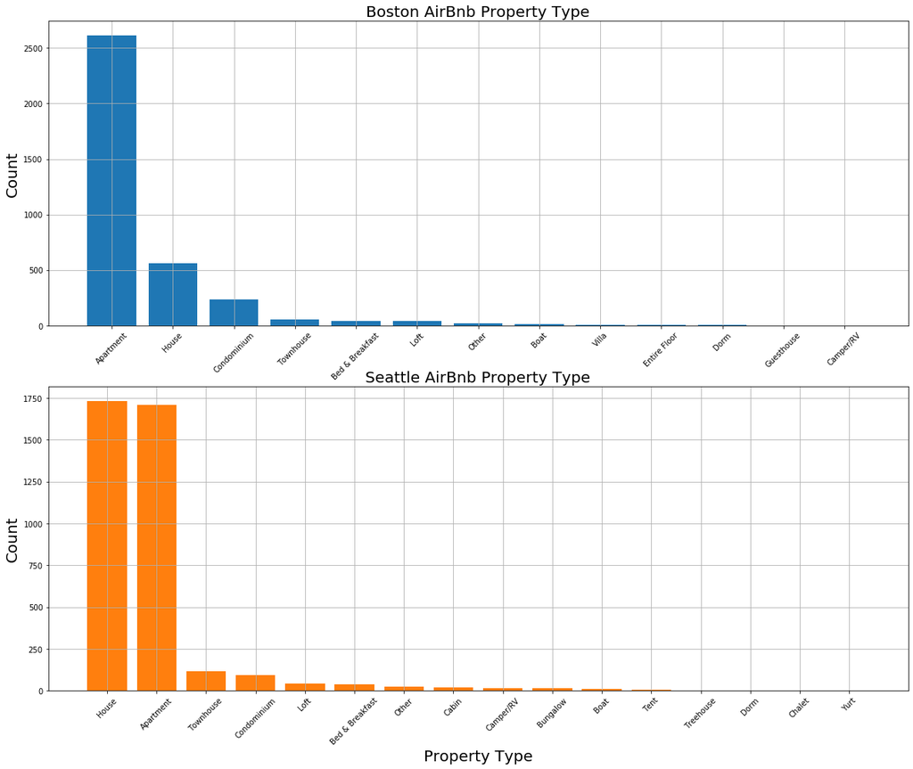

```python
# count plot on property type
fig, ax = plt.subplots(figsize = (20,16))
ax1 = plt.subplot(211)
ax1.set_title('Boston AirBnb Property Type', fontsize=20)
ax1.bar(df_bos_listings['property_type'].value_counts().index,
        df_bos_listings['property_type'].value_counts().values,
        color='tab:blue')
#plt.xlabel('Property Type', fontsize=20)
plt.ylabel('Count', fontsize=20)
plt.xticks(rotation=45)
plt.grid('on')

ax2 = plt.subplot(212)
ax2.set_title('Seattle AirBnb Property Type', fontsize=20)
ax2.bar(df_sea_listings['property_type'].value_counts().index,
        df_sea_listings['property_type'].value_counts().values,
        color='tab:orange')
plt.xlabel('Property Type', fontsize=20)
plt.ylabel('Count', fontsize=20)
plt.xticks(rotation=45)
plt.grid('on')
plt.show()
```

Groupby the room and property types, we can find their individual price.

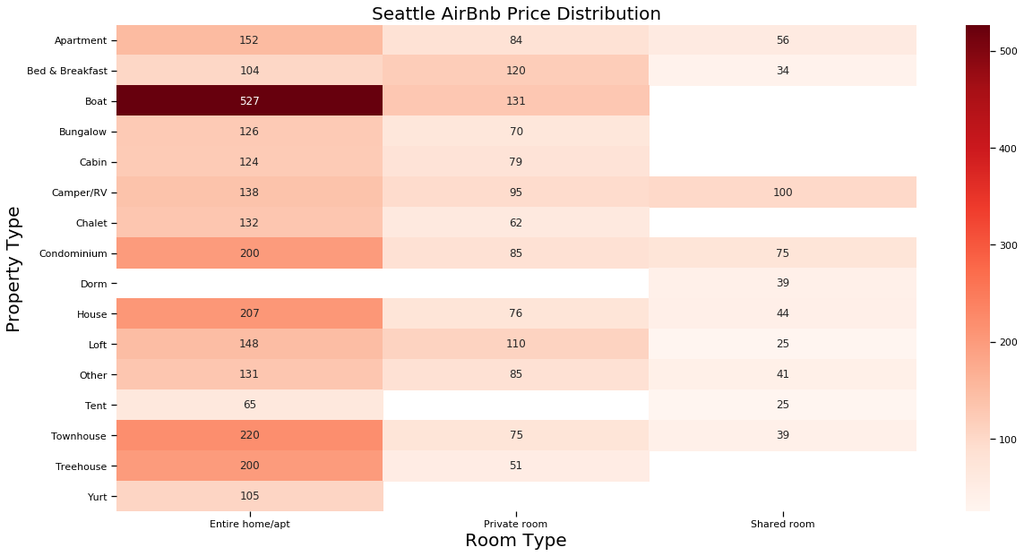

```python
# Seattle mean price on room and property type
with sns.plotting_context("notebook"):
    fig, ax = plt.subplots(figsize = (20,10))
    p1 = sns.heatmap(df_sea_ls_cal.groupby(['property_type','room_type']).price_y.mean().unstack(),cmap="Reds",annot=True, fmt=".0f", ax=ax)
    bottom, top = ax.get_ylim()
    ax.set_ylim(bottom + 0.5, top - 0.5)
    plt.title('Seattle AirBnb Price Distribution', fontsize=20)
    plt.xlabel('Room Type', fontsize=20)
    plt.ylabel('Property Type', fontsize=20)
```

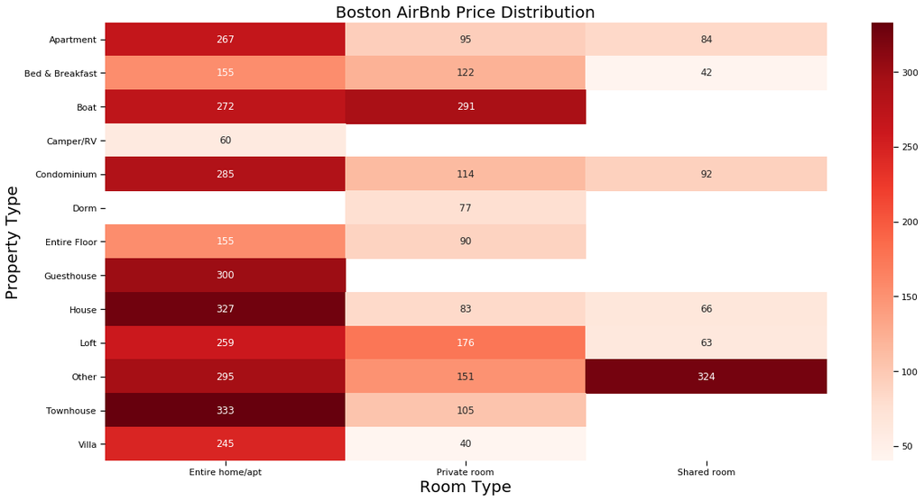

```python
# Boston mean price on room and property type
with sns.plotting_context("notebook"):
    fig, ax = plt.subplots(figsize = (20,10))
    p2 = sns.heatmap(df_bos_ls_cal.groupby(['property_type','room_type']).price_y.mean().unstack(),cmap="Reds",annot=True, fmt=".0f", ax=ax)
    bottom, top = ax.get_ylim()
    ax.set_ylim(bottom + 0.5, top - 0.5)
    plt.title('Boston AirBnb Price Distribution', fontsize=20)
    plt.xlabel('Room Type', fontsize=20)
    plt.ylabel('Property Type', fontsize=20)
```

### 3.4 Rates affected by the neighborhood

For this question, we will look at the neighbourhood_cleansed column, groupby each neighborhood and find its mean price.

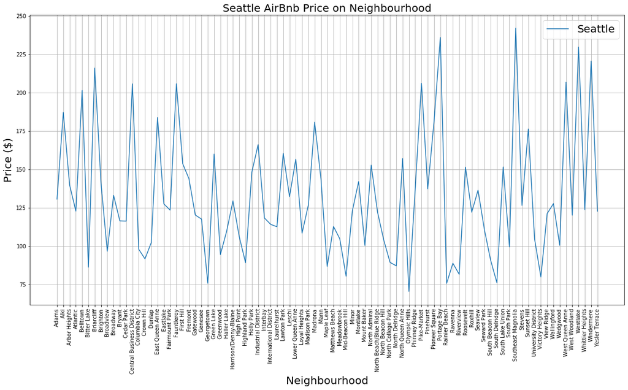

```python
# Seattle AirBnb price on neighbourhood
plt.figure(figsize = (20, 10))
plt.plot(df_sea_ls_cal.groupby(['neighbourhood_cleansed'])['price_y'].mean(), label = 'Seattle')
plt.title('Seattle AirBnb Price on Neighbourhood', fontsize=20)
plt.xlabel('Neighbourhood', fontsize=20)
plt.ylabel('Price ($)', fontsize=20)
plt.legend(fontsize=20)
plt.xticks(rotation=90)
plt.grid('on')
```

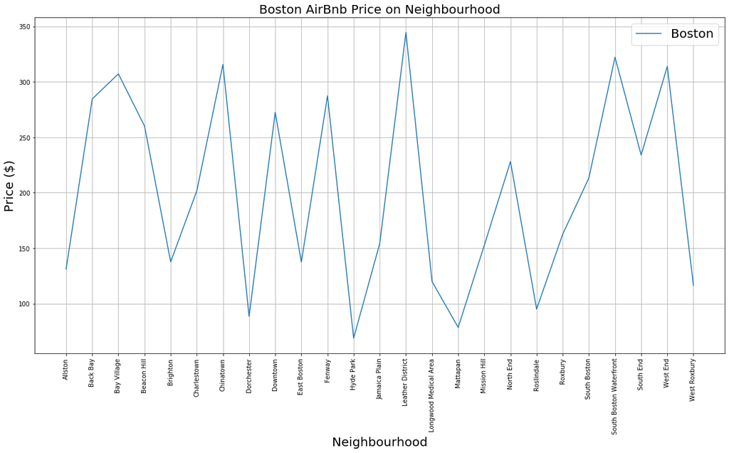

```python
# Boston AirBnb price on neighbourhood
plt.figure(figsize = (20, 10))
plt.plot(df_bos_ls_cal.groupby(['neighbourhood_cleansed'])['price_y'].mean(), label = 'Boston')
plt.title('Boston AirBnb Price on Neighbourhood', fontsize=20)
plt.xlabel('Neighbourhood', fontsize=20)
plt.ylabel('Price ($)', fontsize=20)
plt.legend(fontsize=20)
plt.xticks(rotation=90)
plt.grid('on')
```

### 3.5 Reviews between superhosts and regular hosts

To focus on the reviews, the procedure is as follows, we will need to first separate the rows for superhosts and regular hosts, then pick only the columns that are related to reviews, here are those columns: 'review_scores_rating', 'review_scores_accuracy', 'review_scores_cleanliness', 'review_scores_checkin', 'review_scores_communication', 'review_scores_location', 'review_scores_value'.

For this question, we also need to drop the rows where there are no ratings.

```python
# columns that we will include
rev_cols = ['review_scores_rating', 'review_scores_accuracy',
            'review_scores_cleanliness', 'review_scores_checkin',
            'review_scores_communication', 'review_scores_location',
            'review_scores_value']
```

```python
# separate superhosts from regular hosts
df_sea_super = df_sea_listings[df_sea_listings['host_is_superhost'] == 't']
df_sea_reg = df_sea_listings[df_sea_listings['host_is_superhost'] == 'f']

df_bos_super = df_bos_listings[df_bos_listings['host_is_superhost'] == 't']
df_bos_reg = df_bos_listings[df_bos_listings['host_is_superhost'] == 'f']

# Proportion of Superhosts
print(df_sea_super.shape[0]/df_sea_listings.shape[0])
print(df_bos_super.shape[0]/df_bos_listings.shape[0])
```

```
0.2037716081718177
0.11352859135285913
```

```python
# Dropping NaN Values for review
df_sea_super_reviews = df_sea_super[rev_cols].dropna(subset=['review_scores_rating'])
df_sea_reg_reviews = df_sea_reg[rev_cols].dropna(subset=['review_scores_rating'])

df_bos_super_reviews = df_bos_super[rev_cols].dropna(subset=['review_scores_rating'])
df_bos_reg_reviews = df_bos_reg[rev_cols].dropna(subset=['review_scores_rating'])
```

```python
df_sea_super_reviews.head()
```

|  | review_scores_rating | review_scores_accuracy | review_scores_cleanliness | review_scores_checkin | review_scores_communication | review_scores_location | review_scores_value |
| --- | --- | --- | --- | --- | --- | --- | --- |
| 1 | 96.0 | 10.0 | 10.0 | 10.0 | 10.0 | 10.0 | 10.0 |
| 6 | 99.0 | 10.0 | 10.0 | 10.0 | 10.0 | 10.0 | 10.0 |
| 7 | 97.0 | 10.0 | 10.0 | 10.0 | 10.0 | 9.0 | 10.0 |
| 9 | 97.0 | 10.0 | 10.0 | 10.0 | 10.0 | 10.0 | 9.0 |
| 10 | 97.0 | 10.0 | 10.0 | 10.0 | 10.0 | 10.0 | 10.0 |

```python
# normalize the score rating to 0-10 instead of 0-100
df_sea_super_reviews['review_scores_rating'] /= 10
df_sea_reg_reviews['review_scores_rating'] /= 10
df_bos_super_reviews['review_scores_rating'] /= 10
df_bos_reg_reviews['review_scores_rating'] /= 10
```

```python
# defince a review dataframe that store the ratings
df_reviews = pd.DataFrame(df_sea_super_reviews.mean(), columns=['sea_super'])
df_reviews = df_reviews.join(pd.DataFrame(df_sea_reg_reviews.mean(), columns=['sea_reg']))
df_reviews = df_reviews.join(pd.DataFrame(df_bos_super_reviews.mean(), columns=['bos_super']))
df_reviews = df_reviews.join(pd.DataFrame(df_bos_reg_reviews.mean(), columns=['bos_reg']))
```

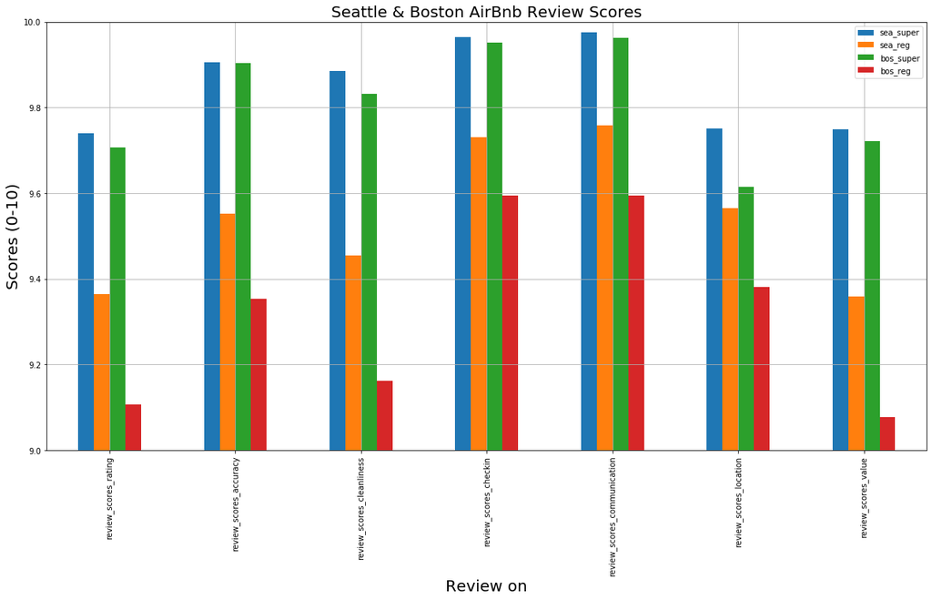

```python
# plot the ratings based on host group
df_reviews.plot(kind='bar', figsize = (20, 10))
plt.title('Seattle & Boston AirBnb Review Scores', fontsize=20)
plt.xlabel('Review on', fontsize=20)
plt.ylabel('Scores (0-10)', fontsize=20)
plt.grid('on')
plt.ylim(9, 10)
plt.legend()
plt.show()
```

## 4. Data Modeling

I will use a linear regression model from sklearn to predict the Airbnb price from some property characteristics, for the properties we will use in the model, I will use the numerial columns that are relatively higher correlated with price, and also the room type column (categorical, we need to use dummy variables).

```python
# find unique properties in the Boston listings dataframe
print (df_sea_listings.shape, df_bos_listings.shape)
print ([x for x in df_bos_listings.columns if x not in df_sea_listings.columns])
```

```
(3818, 92) (3585, 95)
['access', 'interaction', 'house_rules']
```

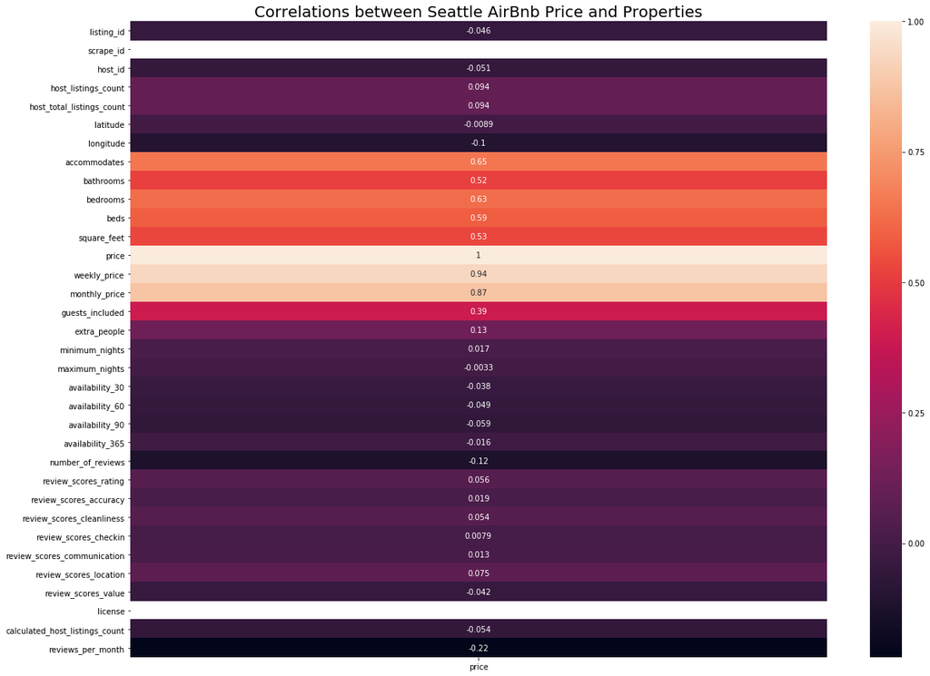

```python
# plot the correlation coefficients to price
fig, ax = plt.subplots(figsize = (20,15))
sns.heatmap(pd.DataFrame(df_sea_listings.corr()['price']), annot = True)
bottom, top = ax.get_ylim()
ax.set_ylim(bottom + 0.5, top - 0.5)
plt.title('Correlations between Seattle AirBnb Price and Properties', fontsize=20)
```

```python
# choose features that are more correlated to price
features = ['price', 'accommodates', 'bathrooms', 'bedrooms', 'beds', 'guests_included', 'extra_people'] + ['room_type']
```

```python
# subset that only contain the selected features
df_model_sea_listings = df_sea_listings[features]
```

```python
# drop NaN for linear regression purpose
df_model_sea_listings = df_model_sea_listings.dropna()
```

```python
df_model_sea_listings.info()
```

```
<class 'pandas.core.frame.DataFrame'>
Int64Index: 3796 entries, 0 to 3817
Data columns (total 8 columns):
price              3796 non-null float64
accommodates       3796 non-null int64
bathrooms          3796 non-null float64
bedrooms           3796 non-null float64
beds               3796 non-null float64
guests_included    3796 non-null int64
extra_people       3796 non-null float64
room_type          3796 non-null object
dtypes: float64(5), int64(2), object(1)
memory usage: 266.9+ KB
```

```python
# get dummies for room type
df_model_sea_listings = pd.get_dummies(df_model_sea_listings, columns = ['room_type'])
```

```python
df_model_sea_listings.head()
```

|  | price | accommodates | bathrooms | bedrooms | beds | guests_included | extra_people | room_type_Entire home/apt | room_type_Private room | room_type_Shared room |
| --- | --- | --- | --- | --- | --- | --- | --- | --- | --- | --- |
| 0 | 85.0 | 4 | 1.0 | 1.0 | 1.0 | 2 | 5.0 | 1 | 0 | 0 |
| 1 | 150.0 | 4 | 1.0 | 1.0 | 1.0 | 1 | 0.0 | 1 | 0 | 0 |
| 2 | 975.0 | 11 | 4.5 | 5.0 | 7.0 | 10 | 25.0 | 1 | 0 | 0 |
| 3 | 100.0 | 3 | 1.0 | 0.0 | 2.0 | 1 | 0.0 | 1 | 0 | 0 |
| 4 | 450.0 | 6 | 2.0 | 3.0 | 3.0 | 6 | 15.0 | 1 | 0 | 0 |

```python
# X y variables for linear regression model
X = df_model_sea_listings.drop(columns = ['price'])
y = df_model_sea_listings['price']

# train test split
X_train, X_test, y_train, y_test = train_test_split(X,y,test_size=0.4, random_state = 42)

# initiate the model
lm_model = LinearRegression(normalize=True)

# fit the model
lm_model.fit(X_train, y_train)

# predict using train set
lm_train = lm_model.predict(X_train)

# predict using test set
lm_test = lm_model.predict(X_test)

# model scores
r2_score_train = r2_score(y_train, lm_train)
r2_score_test = r2_score(y_test,lm_test)

# looking at the coeficients of the model
pd.DataFrame({'variable': X.columns, 'estimate': lm_model.coef_})
```

|  | variable | estimate |
| --- | --- | --- |
| 0 | accommodates | 7.459192 |
| 1 | bathrooms | 32.578820 |
| 2 | bedrooms | 27.168048 |
| 3 | beds | 5.482255 |
| 4 | guests_included | 1.741895 |
| 5 | extra_people | 0.078160 |
| 6 | room_type_Entire home/apt | 24.226059 |
| 7 | room_type_Private room | -19.150952 |
| 8 | room_type_Shared room | -42.294437 |

```python
# print scores
print (r2_score_train, r2_score_test)
```

```
0.5271635027569279 0.5279459109227451
```

We can see this model explains at least 52% of the variations in the price.

## 5. Evaluate the Results

From the price distribution of AirBnb homes in Boston and Seattle, Generally, an AirBnb home in Boston costs 60 dollars more than one Seattle. The most common price of an AirBnb home in Boston ranges from 50 dollars to 200 dollars, whereas in Seattle, you can typically find a good place to stay with no more than 150 dollars.

From the monthly and weekly price distributions of an AirBnb home in Boston and Seattle. Boston sees its peak monthly price in September and October, when the average price of an AirBnb home can reach to around 230 dollars. My assumption is that this price increase results from the high demand from the students. As we know, Boston has many famous colleges and universities, many new students coming in the fall semester (usually in September) might choose to temporarily live in an AirBnb home when they first settle in Boston. Compared with the Boston’s monthly price, we see the Seattle’s monthly price peaks in the summer, with an average cost of around 150 dollars, this increase might be related to the tourists visiting.

From the price history of AirBnb homes in Boston and Seattle, the Seattle data was collected in the 2016 calendar year, whereas the Boston data was collected from 2016–09 to 2017–09, in both curves we can see the price oscillation based on week. While the AirBnb price in Seattle looks more stable, there are some interesting changes in the Boston’s AirBnb average price. First, there is a dramatic decrease in price from 2016–09 to 2017–01, with the average price dropping from around 260 dollars to around 180 dollars. Second, there is a peak price seen on April 17th, 2017, on this day (also days before and after it) we observe a 50 dollars increase in the cost. I checked what happened in Boston on that day out of curiosity, and I suspect it’s related to the Boston Marathon, when many participants flew into the city.

From the monthly occupancy of AirBnb homes in Boston and Seattle, we can see that except in September and October in Boston, you can easily book an AirBnb home because the occupancy in both cities are below 50%. Boston has an occupancy of around 50%, and Seattle has an occupancy of around 35%. However, in September and October in Boston, the occupancy can sometimes reach to up to 70%, and also the prices at this time period are higher as we see in the previous section.

From the counts of different room types and property types that were included in our AirBnb data, I calculated the average price for these different options. In Boston, if your choice is an entire apartment or house, that usually means an average cost of 250 dollars to 350 dollars. If this exceeds your limit, there are also options for a private apartment/house room, which is worth around 90 dollars per night. In Seattle, a private apartment/house room has a similar price of around 80 dollars. For an entire place in Seattle, it is often cheaper than Boston and usually costs no more than 200 dollars.

From the ratings on super hosts vs. regular hosts, on a scale of 0–10, we can see that, on average, super hosts are better rated in terms of information accuracy, home cleanliness, check-in procedure, guest communication, home location and experience value. Super hosts got ratings between 9.6 to 10, whereas regular hosts got ratings between 9.1 to 9.7.

From the correlation figure, we can see that the price is more correlated with some variables like bathrooms, bedrooms, beds, guests allowed, and also the room type. I used a linear regression model on the Seattle AirBnb data and derived an equation: price = estimate * variables where you can calculate an expected AirBnb price given the variables, this model’s accuracy is around 52 percent. It is noted that this model is not 100 percent accurate, there are many extra factors that can affect the price of the AirBnb home.

## 6. Deploy

I created a medium post sharing my findings, the link can be found in the Readme file.